# STAT5630 Final Project – Image Augmentation

Grace Zhou

2026-04-13

```r
load_images_from_csv <- function(csv_data, img_column, label_column) {
  images <- list()
  labels <- c()
  for (i in 1:nrow(csv_data)) {
    img_path <- csv_data[i, img_column]

    if (file.exists(img_path)) {
      img <- image_read(img_path)
      img_array <- as.numeric(image_data(img)) / 255
      images[[length(images) + 1]] <- img_array
      label <- csv_data[i, label_column]
      if(label == "NORMAL") {
        label_num <- 0
      } else {
        label_num <- 1
      }

      labels <- c(labels, label_num)
    }

    if(i %% 500 == 0) cat("Loaded", i, "/", nrow(csv_data), "images\n")
  }

  return(list(images = images, labels = labels))
}

file_paths <- read.csv("file_paths.csv")
file_paths$image_path <- gsub("^chest_xray_resized_new/", "", file_paths$image_path)

all_data <- load_images_from_csv(file_paths, "image_path", "label")
```

```
## Loaded 500 / 5856 images
## Loaded 1000 / 5856 images
## Loaded 1500 / 5856 images
## Loaded 2000 / 5856 images
## Loaded 2500 / 5856 images
## Loaded 3000 / 5856 images
## Loaded 3500 / 5856 images
## Loaded 4000 / 5856 images
## Loaded 4500 / 5856 images
## Loaded 5000 / 5856 images
## Loaded 5500 / 5856 images
```

```r
recreate_labels <- function(csv_data) {
  labels <- c()
  for(i in 1:nrow(csv_data)) {
    if(csv_data$label[i] == "NORMAL") {
      labels <- c(labels, 0)
    } else {
      labels <- c(labels, 1)
    }
  }
  return(labels)
}

clean_labels <- recreate_labels(file_paths)

clean_data <- list(
  images = all_data$images,
  labels = clean_labels
)

train_idx <- which(file_paths$dataset == "train")
val_idx <- which(file_paths$dataset == "val")
test_idx <- which(file_paths$dataset == "test")

train_images <- clean_data$images[train_idx]
train_labels <- clean_data$labels[train_idx]
val_images <- clean_data$images[val_idx]
val_labels <- clean_data$labels[val_idx]
test_images <- clean_data$images[test_idx]
test_labels <- clean_data$labels[test_idx]
```

The training data contained 1,040 normal images for healthy lungs (coded as 0) and 3,144 images for pneumonia lungs (coded as 1), indicating a severe class imbalance issue. To decrease the false positive rate and potentially increase prediction accuracy, image augmentation was applied to achieve class balance. This exposed the model to more diverse features of the dataset to improve predictive performance. Since healthy lungs have clear shapes and edges, the images were slightly rotated with angles ranging from negative 5 to positive 5 degrees. Additionally, to reduce the dependence on raw data features and improve model generalizability, zooming in a randomly picked smaller square area (ranging from 90% to 99% of the original image size) and scaling back to 224×224 were applied to the images. As a result, the normal image count increased from 1,040 to 3,144, achieving a perfectly balanced training set with a 1:1 ratio against the 3,144 pneumonia images, and the total training set expanded from 4,184 to 6,288 images.

```r
# Don't run this!!!! Instead, use balanced_data <- readRDS("../chest_xray_resized_new_2/balanced_data_for_training.rds") instead
train_normal_paths <- file_paths$image_path[which(file_paths$dataset == "train" & file_paths$label == "NORMAL")]

original_normal <- length(train_normal_paths)
pneumonia_count <- sum(train_labels == 1)
need_count <- pneumonia_count - original_normal

cat("Need to create:", need_count, "augmented normal images\n")
```

```
## Need to create: 2104 augmented normal images
```

```r
if (!dir.exists("../chest_xray_resized_new_2")) dir.create("../chest_xray_resized_new_2")
if (!dir.exists("../chest_xray_resized_new_2/train")) dir.create("../chest_xray_resized_new_2/train")
output_dir <- "../chest_xray_resized_new_2/train/NORMAL"
if (!dir.exists(output_dir)) dir.create(output_dir)

rotate <- function(img, d) {
  # d is the degree of rotation
  img <- image_rotate(img, d)
  img_array <- as.integer(image_data(img))
  eff_size <- which.min(apply(img_array, 1, function(x) sum(x!=255))) - 1 # there're some white margins at the right and bottom after rotation, so we need to determine the effectize square area in which the rotated image is located
  l1 <- round(eff_size * abs(sin(d/180*pi))) + 1.5
  l2 <- l1
  new_size <- eff_size - 2*l1 # determine the square area to crop the rotated image in which no white pixels exist
  if (d > 0) { # for clockwise rotation
    img <- image_crop(img, paste0(new_size, "x", new_size, "+", l1-0.5, "+", l2-0.5))
  } else { # for counterclockwise rotation
    img <- image_crop(img, paste0(new_size, "x", new_size, "+", l1/2, "+", l2/2))
  }
  img <- image_scale(img, "224x224") # enlarge to cropped area to 224 x 224
  return(img)
}

zoom_in <- function(img, m) {
  # m is the size of the square area who want to zoom in
  l <- 224 - m
  # (l1,l2) is where we want to place our zoom-in window in terms of (x,y) coordinates (to be randomly selected)
  l1 <- sample(1:l,1)
  l2 <- sample(1:l,1)
  img <- image_crop(img, paste0(m, "x", m, "+", l1, "+", l2))
  img <- image_scale(img, "224") # after selecting the zoom-in area, we need to enlarge it to 224 x 224
  return(img)
}

augment_image <- function(img, type) {
  switch(type,
         "rotate" = rotate(img, sample(c(seq(-5,-0.5,0.5),seq(0.5,5,0.5)), 1)), # randomly choose a rotation angle between -5 and 5, in an interval of 0.5
         "zoom_in" = zoom_in(img, sample(as.integer(224*0.9):223, 1)) # randomly pick a zoom-in window size between 90% and 100%
  )
}

# Generate augmented images
set.seed(5630) # ensure reproducibility of augmented images
types <- c("rotate", "zoom_in")
train_images_augmented <- list()
original_paths_list <- list() # for each generated new image, we want to track its original image
types_list <- list()
for(i in 1:need_count) {
  original_path <- sample(train_normal_paths, 1) # randomly select a NORMAL image from training set
  img <- image_read(original_path)
  aug_type <- sample(types, 1) # randomly choose one of the two image augmentation type
  augmented <- augment_image(img, aug_type)
  train_images_augmented[[i]] <- augmented
  original_paths_list[[i]] <- original_path
  types_list[[i]] <- aug_type # record the type of each augmentation
  if(i %% 500 == 0) cat("Created", i, "/", need_count, "\n")
}
```

```
## Created 500 / 2104
## Created 1000 / 2104
## Created 1500 / 2104
## Created 2000 / 2104
```

```r
# save the augmented images to disk as separate files
df <- data.frame(original=unlist(original_paths_list), augment_type = unlist(types_list))
df <- df %>% group_by(original) %>% mutate(n=row_number(original)) # Due to random sampling, one original image might be used to generate multiple augmentations. So we need to index them in the file name.
fname <- function(x) {
  x <- strsplit(x, '.', fixed=TRUE)[[1]][1]
  x <- rev(strsplit(x, "/", fixed=TRUE)[[1]])[1]
  return(x)
}
new_fpath <- list()
for (i in 1:need_count) {
  new_fname <- paste0(fname(df$original[i]), "_augmentation", df$n[i], ".jpeg")
  new_fpath[[i]] <- paste0("train/NORMAL/", new_fname)
  image_write(train_images_augmented[[i]], path=paste0(output_dir, "/", new_fname), format="jpeg")
}

# bookkeeping for all augmented images
df$file_path <- unlist(new_fpath)
df_save <- df[,c("file_path", "original", "augment_type")]
colnames(df_save)[2] <- "original_image"
write.csv(df_save, "../chest_xray_resized_new_2/augmented_file_paths.csv", row.names = FALSE)

# save the entire (augmented) dataset as an RDS file
train_n <- length(train_images)
for (i in 1:need_count) {
  train_images[[train_n + i]] <- as.integer(image_data(train_images_augmented[[i]]))
  train_labels[[train_n + i]] <- 0
}
saveRDS(list(
  train_images = train_images,
  train_labels = train_labels,
  val_images = val_images,
  val_labels = val_labels,
  test_images = test_images,
  test_labels = test_labels
), "../chest_xray_resized_new_2/balanced_data_for_training.rds")
```

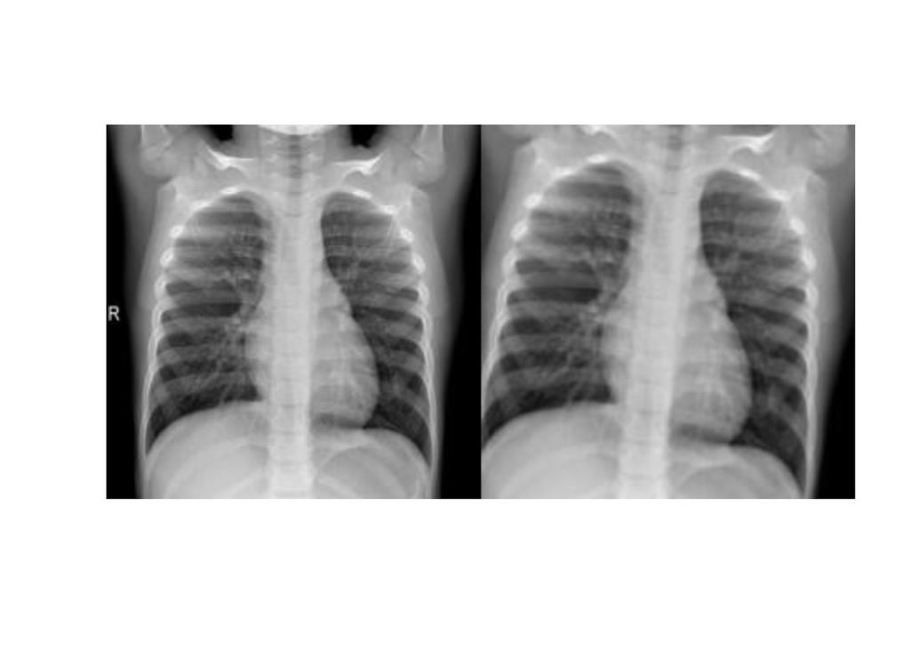

```r
# An example of rotated image
set.seed(123)
rotate_df <- df[df$augment_type == "rotate",]
rotate_sample <- rotate_df[sample(1:nrow(rotate_df), 1),]
img1 <- image_read(rotate_sample$original[1])
img2 <- image_read(paste0(output_dir, "/", fname(rotate_sample$original[1]), "_augmentation", rotate_sample$n[1], ".jpeg"))
combined <- image_append(c(img1, img2), stack = FALSE)
plot(combined)
```

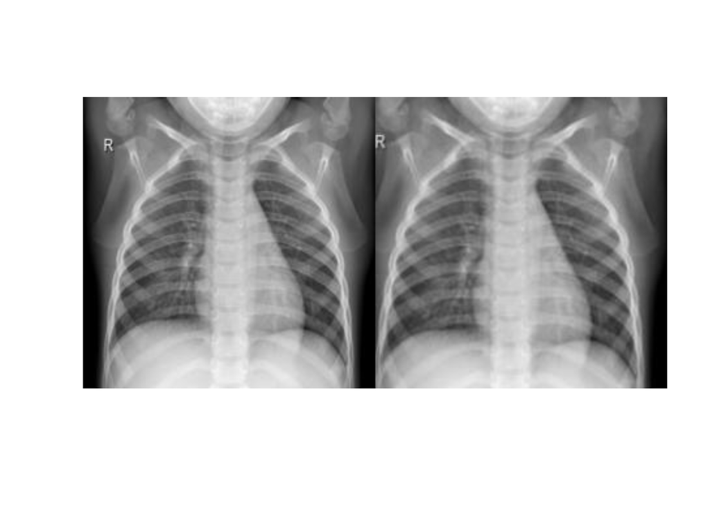

```r
# An example of zoomed-in image
set.seed(1234)
zoom_in_df <- df[df$augment_type == "zoom_in",]
zoom_in_sample <- zoom_in_df[sample(1:nrow(zoom_in_df), 1),]
img1 <- image_read(zoom_in_sample$original[1])
img2 <- image_read(paste0(output_dir, "/", fname(zoom_in_sample$original[1]), "_augmentation", zoom_in_sample$n[1], ".jpeg"))
combined <- image_append(c(img1, img2), stack = FALSE)
plot(combined)
```

```r
# copy/paste all original image files to the new folder "chest_xray_resized_new_2"
files_to_copy <- list.files("train/NORMAL", full.names = TRUE)
file.copy(from = files_to_copy, to = "../chest_xray_resized_new_2/train/NORMAL", overwrite = FALSE)
```

[output not shown]

[output cut: 60 more lines]

```r
file.copy(from = "train/PNEUMONIA",
          to = "../chest_xray_resized_new_2/train",
          recursive = TRUE,
          copy.mode = TRUE)
```

```
## [1] TRUE
```

```r
if (!dir.exists("../chest_xray_resized_new_2/val")) dir.create("../chest_xray_resized_new_2/val")
file.copy(from = "val/PNEUMONIA",
          to = "../chest_xray_resized_new_2/val",
          recursive = TRUE,
          copy.mode = TRUE)
```

```
## [1] TRUE
```

```r
file.copy(from = "val/NORMAL",
          to = "../chest_xray_resized_new_2/val",
          recursive = TRUE,
          copy.mode = TRUE)
```

```
## [1] TRUE
```

```r
if (!dir.exists("../chest_xray_resized_new_2/test")) dir.create("../chest_xray_resized_new_2/test")
file.copy(from = "test/PNEUMONIA",
          to = "../chest_xray_resized_new_2/test",
          recursive = TRUE,
          copy.mode = TRUE)
```

```
## [1] TRUE
```

```r
file.copy(from = "test/NORMAL",
          to = "../chest_xray_resized_new_2/test",
          recursive = TRUE,
          copy.mode = TRUE)
```

```
## [1] TRUE
```

```r
file.copy(from = "file_paths.csv",
          to = "../chest_xray_resized_new_2/file_paths.csv",
          copy.mode = TRUE)
```

```
## [1] TRUE
```